# NE04_Create_Seurat_cluster_and_annotate

Spyros Darmanis

3/12/2019

Load libraries

Set directory This is used to save within the repo All paths can be changed accordingly

```r
# rm(list=ls())
dir <- "/Users/spyros/Documents/Labwork/Projects/Biohub/NE_Lung/"
```

Run the following chuck if you want just NE cells doublets included

Run the following chuck if you want just NE cells doublets excluded

Run the following chuck if you want ALL cells (+additional datasets) cells doublets excluded Load data

```r
data_adult <- read.table(paste(dir,"input/GC_table_ALL_datasets.tsv",sep=""))
meta_adult_new <- read.table(paste(dir,"input/Metadata_ALL_datasets.tsv",sep=""))
```

Create Seurat object of whichever dataset you decided to use

```r
require(Seurat)
tiss <- CreateSeuratObject(raw.data = data_adult, project = "NE_Lung", meta.data = meta_adult_new,
                           display.progress = T)
tiss <- AddMetaData(object = tiss, metadata = meta_adult_new)
# save(tiss, file = paste(dir,"input/NE_Lung_Seurat.RData",sep=""))
```

Filter the dataset and preprocess Filtering on 1000 genes minimum and 50000 reads minimum per cell

```r
tiss <- FilterCells(object = tiss, subset.names = c("nGene", "nUMI"),
    low.thresholds = c(1000, 50000), high.thresholds = c(Inf, Inf))
tiss
```

```
## An object of class seurat in project NE_Lung
##  23316 genes across 2727 samples.
```

Preprocess data

```r
tiss <- NormalizeData(object = tiss, normalization.method = "LogNormalize",
    scale.factor = 1000000)
tiss <- ScaleData(object = tiss, do.scale = T, do.center = T)
```

```
## Scaling data matrix
```

Find variable genes

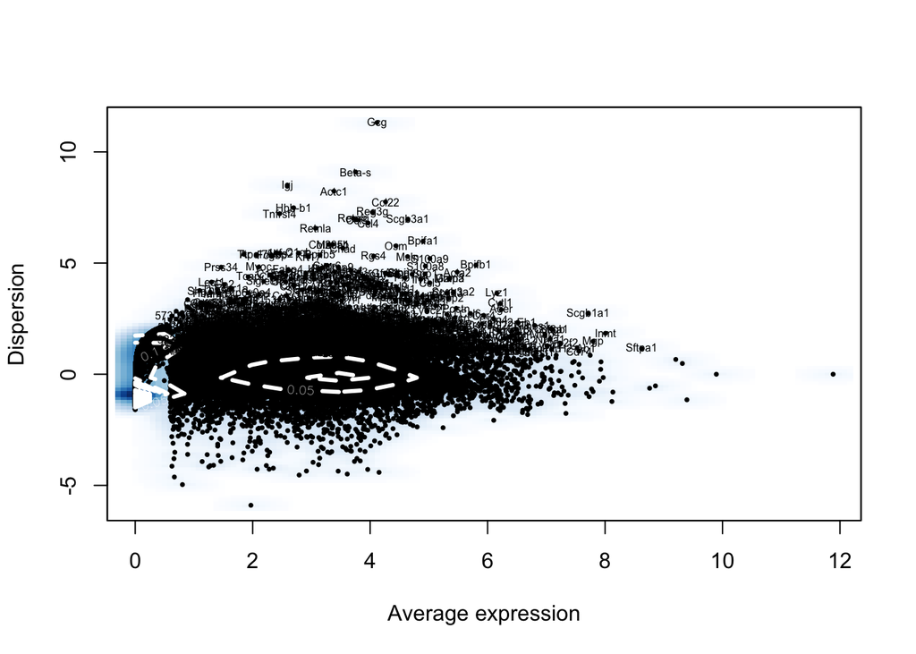

```r
tiss <- FindVariableGenes(object = tiss, do.plot = TRUE, x.high.cutoff = Inf, y.cutoff = 1, num.bin = 20,
                                          binning.method = "equal_width", do.recalc = T, x.low.cutoff=1)
```

Perform PCA

```r
tiss <- RunPCA(object = tiss, do.print = FALSE)
tiss <- ProjectPCA(object = tiss, do.print = FALSE)
```

Visualize top genes across principal components

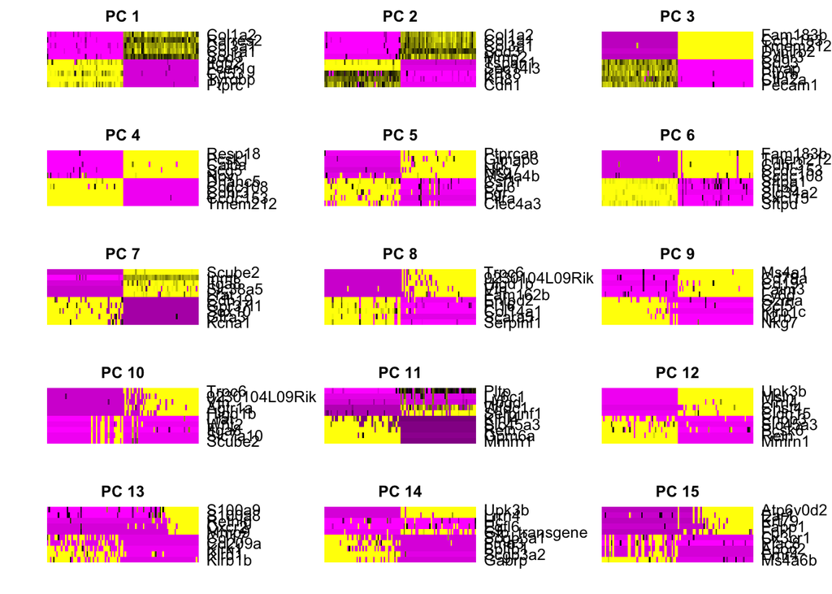

```r
PCHeatmap(object = tiss, pc.use = 1:15, cells.use = 100, do.balanced = TRUE, label.columns = FALSE, num.genes = 10)
```

Perform correlation of PCs and metadata fields

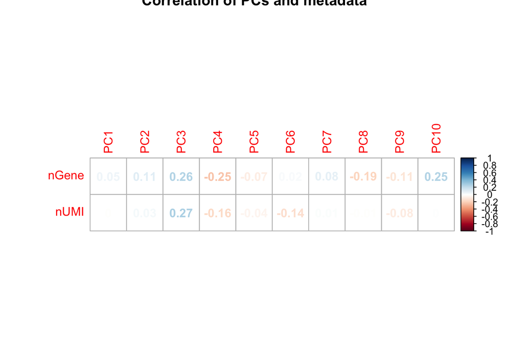

```r
pca.obj <- tiss@dr$pca
pc.coords <- pca.obj@cell.embeddings
df1 <- tiss@meta.data[,c("nGene","nUMI")]
df2 <- pc.coords[,c(1:10)]
cordf12 <- cor(df1,df2)
# Make a correlation plot
corrplot(cordf12, method = "number", main="Correlation of PCs and metadata")
```

Also visaulize PC variance

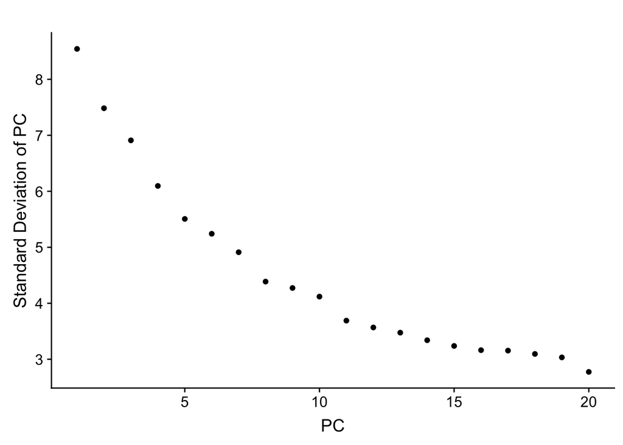

```r
#comp.dev <-pca.obj@sdev
PCElbowPlot(object = tiss)
```

Plot a few of the principal components

```r
temp <- tiss@dr$pca@cell.embeddings
temp <- as.data.frame(temp)
names <- colnames(temp)
temp <- cbind(temp, tiss@meta.data$dataset)
colnames(temp) <- c(names, "dataset")
pca.scatter = ggpairs(data=temp,
             columns=1:10,
             upper = list(continuous = "points"),
             lower = list(combo = "na"),
             mapping=ggplot2::aes(colour = dataset), legend = 2) + theme(legend.position = "bottom")
ggsave(plot = pca.scatter, filename = "~/Documents/Labwork/Projects/Biohub/NE_Lung/plot_out/NE04/PCA_scatterplots_largefile.pdf",width = 15, height = 12)
```

Choose the number of principal components to use.

```r
n.pcs = 10
```

Set resolution and perform clustering

```r
res.used <- 0.3
tiss <- FindClusters(object = tiss, reduction.type = "pca", dims.use = 1:n.pcs,
    resolution = res.used, print.output = 0, save.SNN = TRUE, k.param = 5)
```

Perform tSNE

```r
set.seed(123)
tiss <- RunTSNE(object = tiss, dims.use = 1:n.pcs, seed.use = 10, perplexity=30)
```

Visualize TSNE colored by cluster

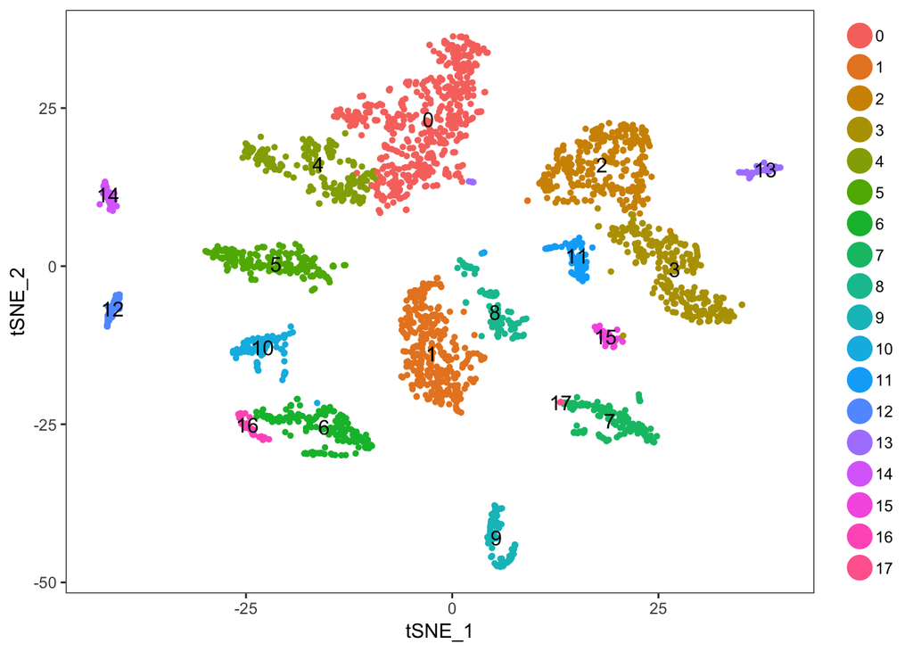

```r
TSNEPlot(object = tiss, do.label = T)
```

Plot the fraction of each dataset in each

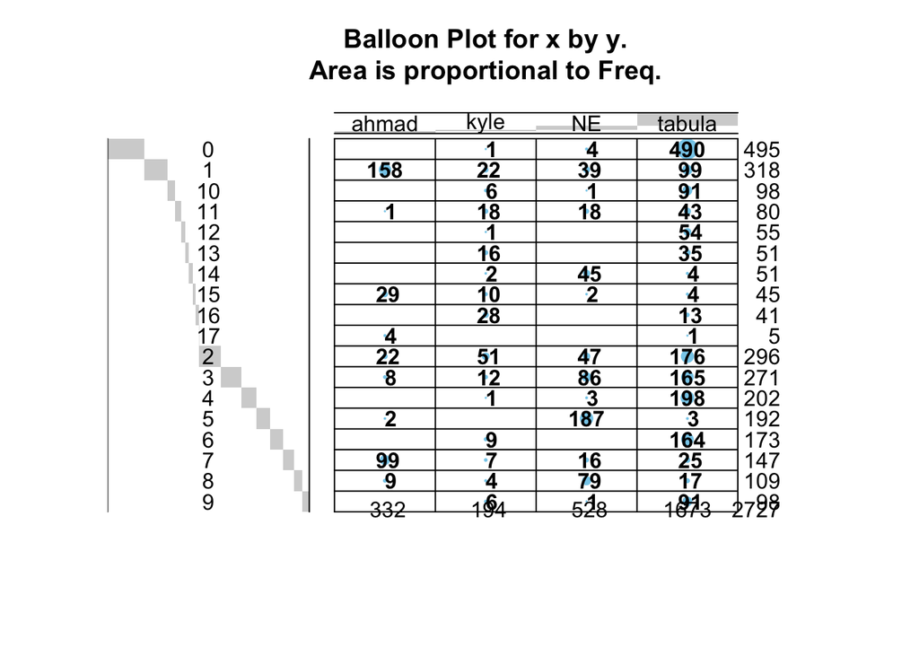

```r
tab.1 <- table(tiss@meta.data$dataset,tiss@meta.data$res.0.3)
balloonplot(tab.1)
```

Color by a gene. Feature plot

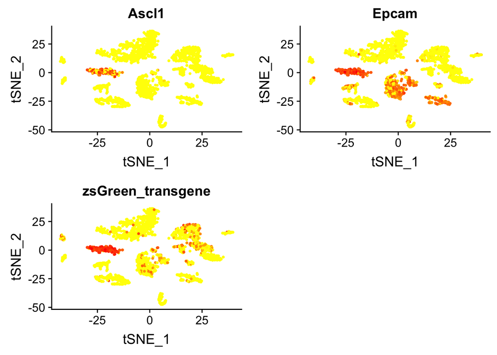

```r
FeaturePlot(tiss, c("Ascl1", "Epcam", "zsGreen_transgene"))
```

Color by a gene. Dot plot

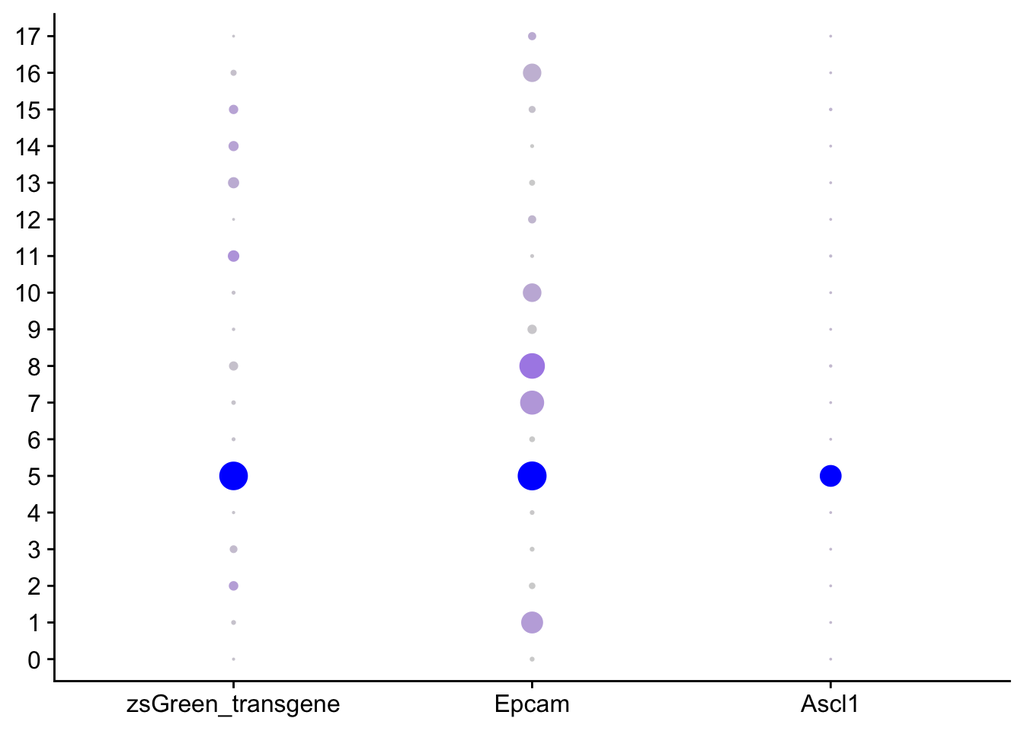

```r
DotPlot(tiss, c("Ascl1", "Epcam", "zsGreen_transgene"))
```

Visualize TSNE metadata field Experiment ID

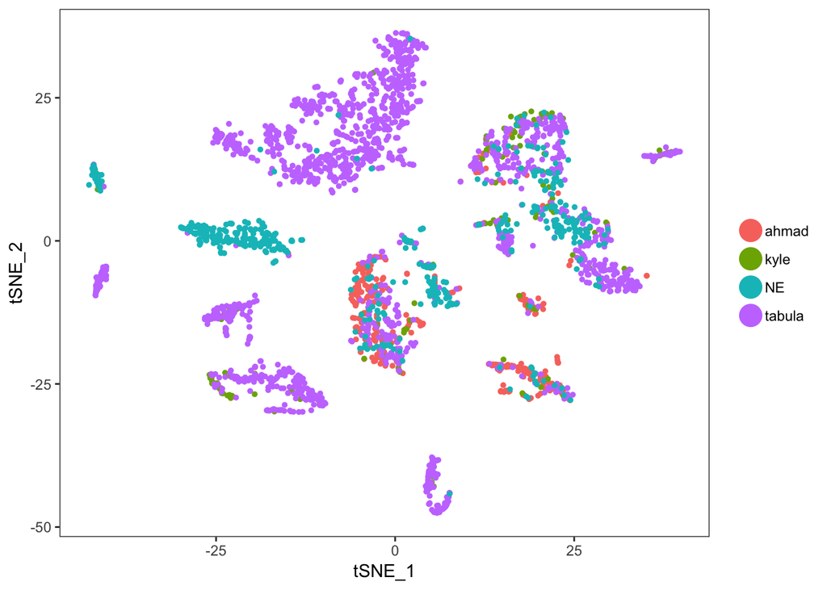

```r
# note that you can set do.label=T to help label individual clusters
TSNEPlot(object = tiss, do.label = F, group.by = "dataset")
```

Save object

```r
save(tiss,file=paste(dir,"input/All_datasets_ND.RData",sep=""))
```